# MR and colocalisation of DNAm on tissue counts

Gibran Hemani

```r
suppressWarnings(suppressPackageStartupMessages({
    library(dplyr)
    library(magrittr)
    library(data.table)
    library(ggplot2)
    library(tidyr)
    library(knitr)
    library(pander)
}))
opts_chunk$set(cache=TRUE, echo=TRUE, message=FALSE, warning=FALSE)
```

Read in data

```r
load("results/cellcount_coloc.rdata")
load("results/cellcount_mr.rdata")
mrivw$fdr <- p.adjust(mrivw$pval, "fdr")
wr$fdr <- p.adjust(wr$pval, "fdr")
```

Significant ivw

```r
mrivw_sig <- subset(mrivw, fdr < 0.05)
nrow(mrivw_sig) / nrow(mrivw)
```

```
## [1] 0.01630987
```

Significant hits more likely when number of instruments is larger

```r
table(mrivw_sig$nsnp) / table(mrivw$nsnp)
```

```
##
##          2          3          4          5          6          7
## 0.01584892 0.01602472 0.02361833 0.03318803 0.02875790 0.05765199
##          8          9
## 0.01176471 0.17647059
```

```r
summary(glm(I(fdr < 0.05) ~ nsnp, mrivw, family="binomial")) %>% pander::pander()
```

|  | Estimate | Std. Error | z value | Pr(>\|z\|) |
| --- | --- | --- | --- | --- |
| **(Intercept)** | -4.464 | 0.01933 | -231 | 0 |
| **nsnp** | 0.157 | 0.007893 | 19.89 | 4.928e-88 |

(Dispersion parameter for binomial family taken to be 1 )

| Null deviance: | 370938 on 2226319 degrees of freedom |
| --- | --- |
| Residual deviance: | 370572 on 2226318 degrees of freedom |

Significant wr

```r
wr_sig <- subset(wr, fdr < 0.05 & nsnp == 1)
table(wr_sig$method) %>% pander::pander()
```

| Inverse variance weighted | Wald ratio |
| --- | --- |
| 0 | 574891 |

```r
table(wr_sig$nsnp) %>% pander::pander()
```

| 1 |
| --- |
| 574891 |

```r
table(wr$nsnp) %>% pander::pander()
```

| 1 | 2 | 3 |
| --- | --- | --- |
| 9567947 | 5188 | 35 |

Check that the WR and coloc analyses have the same data

```r
res$id.exposure <- paste(res$variant, res$cpg)
rescheck <- subset(res, paste(id.exposure, trait) %in% paste(wr_sig$id.exposure, wr_sig$id.outcome))
dim(rescheck) %>% pander::pander()
```

*574891* and *15*

```r
dim(wr_sig) %>% pander::pander()
```

*574891* and *10*

Coloc

```r
table(rescheck$nsnps > 10) %>% pander::pander()
```

| FALSE | TRUE |
| --- | --- |
| 60628 | 513203 |

```r
table(rescheck$PP.H4.abf > 0.8 & rescheck$nsnps > 10) %>% pander::pander()
```

| FALSE | TRUE |
| --- | --- |
| 479093 | 94738 |

## Comparing colocalising associations against secondary mQTLs

Find colocalising hits

```r
wr <- wr %>% tidyr::separate(exposure, sep=" ", into=c("variant", "cpg"), remove=FALSE)

# Get significant wr
wr_sig <- subset(wr, fdr < 0.05)

# Which colocalise?
wr_coloc <- inner_join(
    wr_sig,
    subset(res, PP.H4.abf > 0.8 & nsnps > 10),
    by=c("id.exposure", "outcome"="trait")
)
```

Which of these cpgs have a secondary mqtl?

```r
cpg_trait <- unique(paste(wr_coloc$cpg.x, wr_coloc$outcome))
wr_cpg_trait <- subset(wr, paste(cpg, outcome) %in% cpg_trait)
wr_cpg_trait$cpgtrait <- paste(wr_cpg_trait$cpg, wr_cpg_trait$outcome)
table(table(wr_cpg_trait$cpgtrait)) %>% pander::pander()
```

| 1 | 2 | 3 | 4 | 5 | 6 | 7 | 8 | 9 |
| --- | --- | --- | --- | --- | --- | --- | --- | --- |
| 42126 | 22067 | 14897 | 6975 | 3385 | 1416 | 354 | 68 | 15 |

Separate the primary and separate coloc signals

```r
wr_cpg_trait_primary <- subset(wr_cpg_trait, paste(id.exposure, outcome) %in% paste(wr_coloc$id.exposure, wr_coloc$id.outcome))

wr_cpg_trait_secondary <- subset(wr_cpg_trait, !paste(id.exposure, outcome) %in% paste(wr_coloc$id.exposure, wr_coloc$id.outcome))
```

For every cpg-trait pair, meta analyse the results to get a single assoc. Essentially creating the IVW fixed effects estimate from the Wald ratios

```r
cpg_trait_list <- unique(paste(wr_cpg_trait$cpg, wr_cpg_trait$outcome))
metafn <- function(x)
{
    m <- meta::metagen(x$b, x$se)
    y <- tibble(
        nsnp=nrow(x),
        b=m$TE.fixed,
        se=m$seTE.fixed,
        pval=m$pval.fixed
    )
    y
}
out <- wr_cpg_trait_secondary %>%
    group_by(cpgtrait) %>%
    do(metafn(.))
```

Combine primary and secondary results

```r
ps <- inner_join(wr_cpg_trait_primary, out, by="cpgtrait")
ps$fdr.y <- p.adjust(ps$pval.y, "fdr")
ps$fdr.x <- p.adjust(ps$pval.x, "fdr")
save(ps, file="results/primary-secondary.rdata")
```

Check all primary associations have fdr < 0.05

```r
table(ps$fdr.x < 0.05) %>% pander::pander()
```

| TRUE |
| --- |
| 50782 |

How many secondary associations have fdr < 0.05?

```r
table(ps$fdr.y < 0.05) %>% pander::pander()
```

| FALSE | TRUE |
| --- | --- |
| 35409 | 15373 |

We should remove chromosome 6 to be careful about MHC region

```r
table(ps$fdr.y[!grepl("6:", ps$variant)] < 0.05) %>% pander::pander()
```

| FALSE | TRUE |
| --- | --- |
| 23238 | 4900 |

Looks like a lot of this is from the MHC region.

Are the primary and secondary effects correlated?

```r
summary(lm(b.y ~ b.x, ps)) %>% pander::pander()
```

|  | Estimate | Std. Error | t value | Pr(>\|t\|) |
| --- | --- | --- | --- | --- |
| **(Intercept)** | 0.001699 | 0.0003603 | 4.715 | 2.425e-06 |
| **b.x** | 0.08542 | 0.001436 | 59.47 | 0 |

Fitting linear model: b.y ~ b.x

| Observations | Residual Std. Error | $R^2$ | Adjusted $R^2$ |
| --- | --- | --- | --- |
| 50782 | 0.08119 | 0.06512 | 0.0651 |

This effect attenuates sharply after removing MHC

```r
summary(lm(b.y ~ b.x, ps %>% subset(., !grepl("6:", variant)))) %>% pander::pander()
```

|  | Estimate | Std. Error | t value | Pr(>\|t\|) |
| --- | --- | --- | --- | --- |
| **(Intercept)** | 0.0006889 | 0.0003654 | 1.885 | 0.05942 |
| **b.x** | 0.03129 | 0.00202 | 15.49 | 6.276e-54 |

Fitting linear model: b.y ~ b.x

| Observations | Residual Std. Error | $R^2$ | Adjusted $R^2$ |
| --- | --- | --- | --- |
| 28138 | 0.06129 | 0.008461 | 0.008426 |

Look at the plots

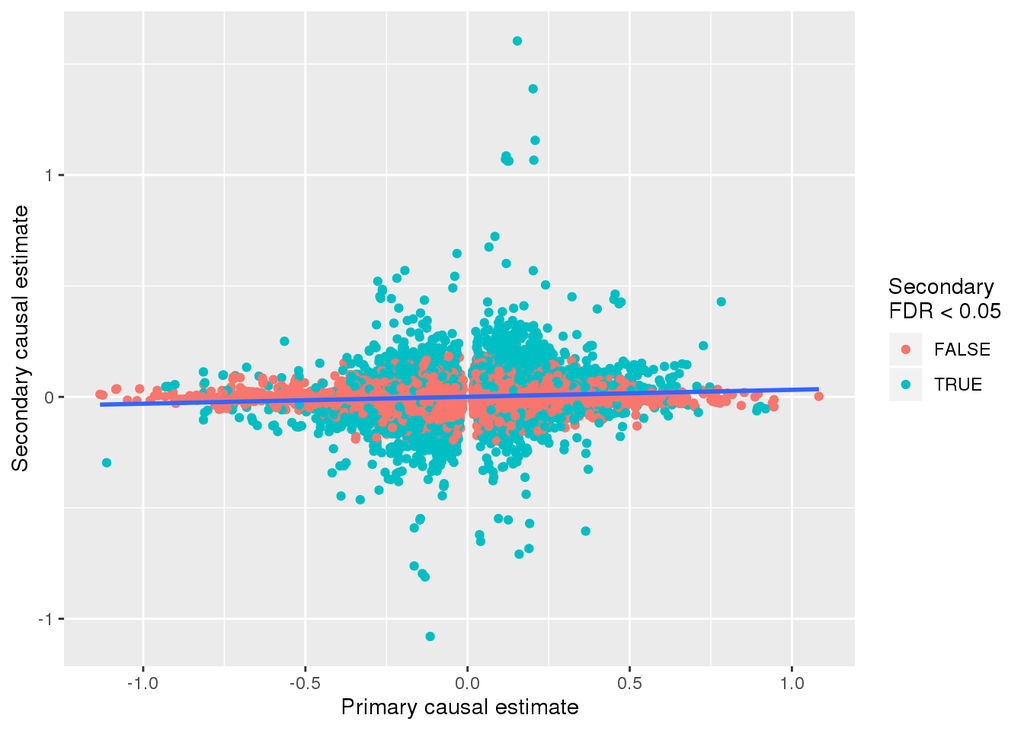

```r
ggplot(ps %>% subset(., !grepl("6:", variant)), aes(x = b.x, y = b.y)) +
geom_point(aes(colour=fdr.y < 0.05)) +
geom_smooth(method="lm") +
labs(x="Primary causal estimate", y="Secondary causal estimate", colour="Secondary\nFDR < 0.05")
```

A lot of significant results secondary effects, but not much of a relationship between primary and secondary hits.

How does it compare by splitting by number of instruments used for secondary association?

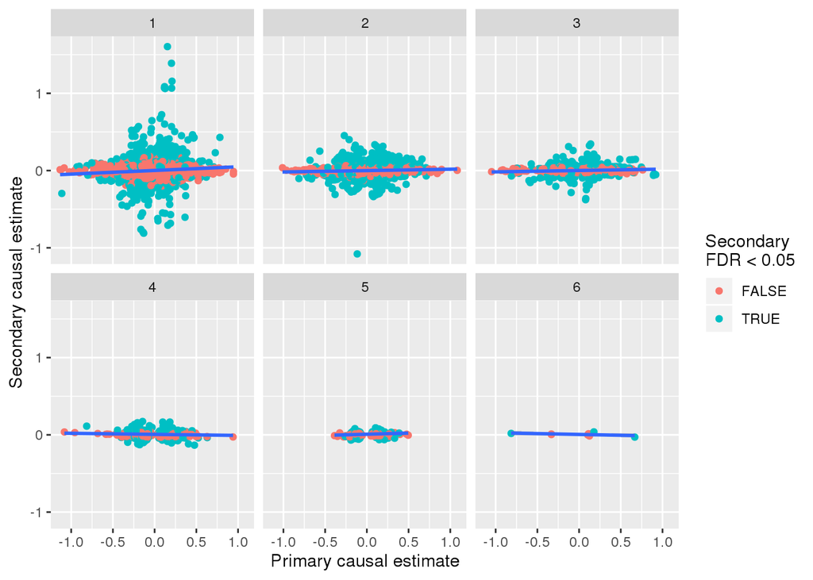

```r
ggplot(ps %>% subset(., !grepl("6:", variant)), aes(x = b.x, y = b.y)) +
geom_point(aes(colour=fdr.y < 0.05)) +
geom_smooth(method="lm") +
facet_wrap(~ nsnp.y) +
labs(x="Primary causal estimate", y="Secondary causal estimate", colour="Secondary\nFDR < 0.05")
```

What are the primary-secondary associations?

```r
assocfn <- function(x)
{
    mod <- summary(lm(b.y ~ b.x, x))$coefficients
    data.frame(nassoc=nrow(x), b=mod[2,1], se=mod[2,2], p=mod[2,4])
}

ps %>%
    subset(., !grepl("6:", variant)) %>%
    group_by(nsnp=nsnp.y) %>%
    do(assocfn(.)) %>%
    pander()
```

| nsnp | nassoc | b | se | p |
| --- | --- | --- | --- | --- |
| 1 | 15357 | 0.04754 | 0.003452 | 6.678e-43 |
| 2 | 8519 | 0.01797 | 0.00262 | 7.324e-12 |
| 3 | 3066 | 0.01787 | 0.003329 | 8.596e-08 |
| 4 | 917 | -0.01366 | 0.005672 | 0.01622 |
| 5 | 270 | 0.02947 | 0.009731 | 0.002701 |
| 6 | 9 | -0.02171 | 0.01542 | 0.2021 |

Group by blood cell trait category

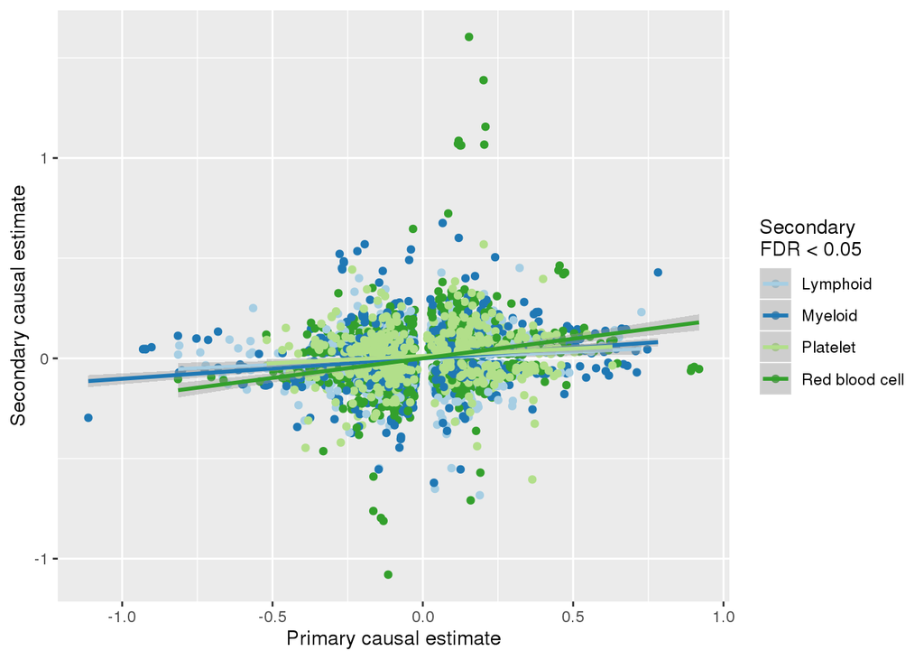

```r
load("bc_type/bc_type.rdata")
bcm$id <- gsub("ebi-a-", "", bcm$id)
stopifnot(all(ps$id.outcome %in% bcm$id))
ps <- inner_join(ps, subset(bcm, select=c(trait, id, type)), by=c("id.outcome"="id"))

ggplot(ps %>% subset(., !grepl("6:", variant) & fdr.y < 0.05), aes(x = b.x, y = b.y)) +
geom_point(aes(colour=type)) +
geom_smooth(method="lm", aes(color=type)) +
labs(x="Primary causal estimate", y="Secondary causal estimate", colour="Secondary\nFDR < 0.05") +
scale_colour_brewer(type="qual", palette=3)
```

Coefficients

```r
ps %>%
    subset(., !grepl("6:", variant) & fdr.y < 0.05) %>%
    group_by(type=type) %>%
    do(assocfn(.)) %>%
    pander()
```

| type | nassoc | b | se | p |
| --- | --- | --- | --- | --- |
| Lymphoid | 960 | 0.06633 | 0.0189 | 0.0004683 |
| Myeloid | 1702 | 0.1027 | 0.01347 | 4.143e-14 |
| Platelet | 865 | 0.07294 | 0.0195 | 0.0001955 |
| Red blood cell | 1373 | 0.1953 | 0.02217 | 3.656e-18 |